# 00 - Data Analytics with R

David Zimmermann

2016-10-07

# Outline

# What we are going to do

- Fri: R Programming
- Sat: Data Science with R (Data Munging)
- Sun: Data Visualization

# What we are going to leave out

- Statistics & Inference
- Machine Learning & Artificial Intelligence
- High-Performance Computing & “Big Data”

If you are interested maybe next time

# Idea of the Workshop

Each day 10-16h, this room

Theoretical input by me, exercises at the end of most sections

Solutions will be posted to: https://github.com/DavZim/RDataAnalytics

# R

# What is R?

[video not shown]

# Spreadsheets (such as Excel)?

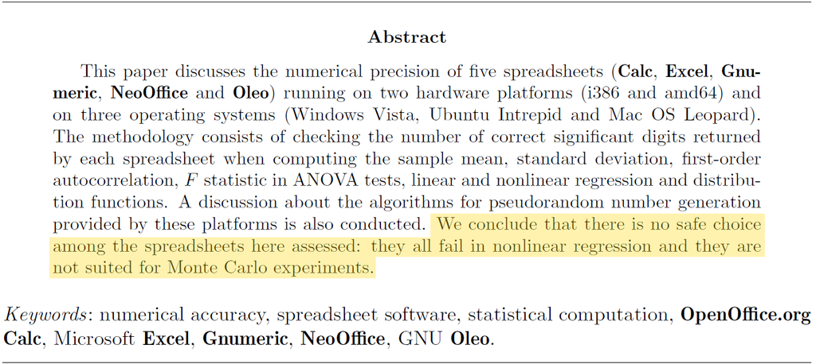

Source: Almiron et al. (2010): On the Numerical Accuracy of Spreadsheets https://www.jstatsoft.org/article/view/v034i04 Further Motivation:

- Excel Errors and Science Papers: http://www.economist.com/blogs/graphicdetail/2016/09/daily-chart-3
- Herndon vs. Reinhart, Rogoff: http://www.bbc.com/news/magazine-22223190
- https://baselinescenario.com/2013/02/09/the-importance-of-excel/
- http://www.zerohedge.com/news/2013-02-12/how-rookie-excel-error-led-jpmorgan-misreport-its-var-years

# Why use R? - Popularity

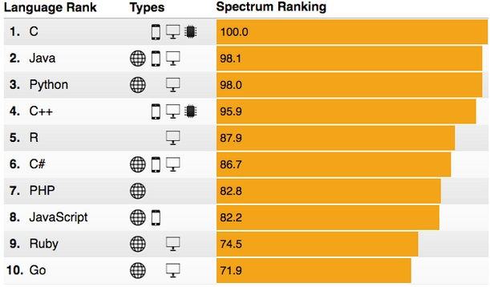

Source: http://spectrum.ieee.org/computing/software/the-2016-top-programming-languages

# Why use R? - Usage

[figure not shown]

Source: http://blog.revolutionanalytics.com/2014/05/companies-using-r-in-2014.html

# Why use R? - Open Source

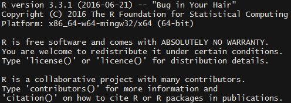

License: https://www.r-project.org/Licenses/GPL-3

- Free of charge
- Distribute as you like
- Open source code
- Contribute

# Why use R? - Community

### CRAN Task Views

Special (curated) lists for topics such as: Bayesian, Cluster, Econometrics, Finance, Graphics, MachineLearning, NaturalLanguageProcessing, Spatial, or TimeSeries

https://cran.r-project.org/web/views/

### StackOverflow

# Why use R? - Community cont’d

### Packages Libraries

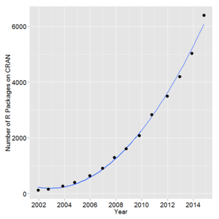

Source: http://blog.revolutionanalytics.com/2016/04/cran-package-growth.html

# Why use R? - Community cont’d

### Blogs

[figure not shown]

Source: https://www.r-bloggers.com/

# Why use R? - Documentation

### Help Functions

Asking yourself what function `plot` does, what arguments it takes, how to use/tweak it?

`?plot`: Inside of R, built-in help

If that doesn’t help: Google and/or StackOverflow

# Potential Goals

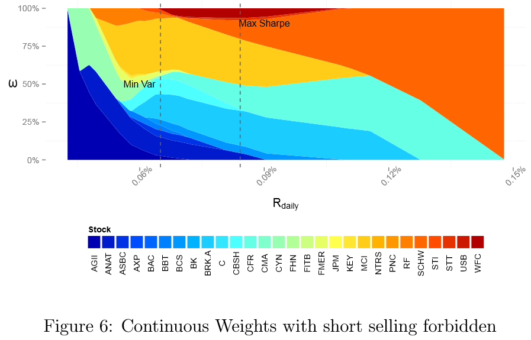

Source: Author’s own creation

# Potential Goals cont’d

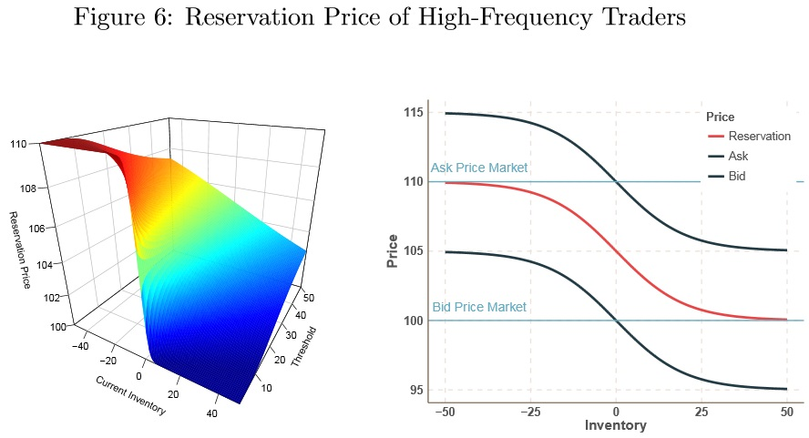

Source: Author’s own creation

# Potential Goals cont’d

[figure not shown]

Source: http://blog.revolutionanalytics.com/2010/12/facebooks-social-network-graph.html https://www.facebook.com/notes/facebook-engineering/visualizing-friendships/469716398919

# Getting down to R

# Installing R and RStudio

R: https://cran.r-project.org/

RStudio: https://www.rstudio.com/products/RStudio/

# RStudio

# RStudio

[figure not shown]

# Demonstration

# RMarkdown

Another option to scripting. Output is by default a html-page or a pdf.

Use markdown for writing, insert r-code chunks with (`cmd/strg` + `alt` + `i` or click “insert new code chunk”) and hit `knit` to create the output

> Demonstration

# Additional Information

# Learning R elsewhere

- http://swirlstats.com/students.html
- http://tryr.codeschool.com
- https://cran.r-project.org/doc/contrib/Torfs+Brauer-Short-R-Intro.pdf
- https://www.datacamp.com/courses/free-introduction-to-r/
- https://www.rstudio.com/online-learning/#R
- http://www.ats.ucla.edu/stat/r/
- https://cran.r-project.org/doc/manuals/r-release/R-intro.pdf
- http://r4ds.had.co.nz/
- Reproducible Resarch: http://kbroman.org/pages/tutorials.html